# reading_mat

Xiaoni Xu

2024-11-18

Loading needed packages

```r
library(R.matlab)
```

```r
library(ggplot2)
library(MHD)
library(manifold)
```

There are 5 shape metrics used: elastic scaled metric, elastic unscaled metric with elastic representation of shapes, Full Procrustes metric, Kendall scaled metric, Kendall unscaled metric with Kendall’s representation of shapes.

Data in nested sturcture: factor-cell, animal, type of mitochondria (SS/IMF), exercise(Running/Sedentary)

### Reading `Allshape.mat`

`Allshape.mat` contains a large 3D array containing mitochondrial shape data for multiple animals and cells.

AllShape.mat contains all the reampled boundary, to make the code run faster we resample 50 points on the boundary. %%%Data: 12 animal in total.X1,X2,…,X12 %%%Each animal contain several cells: 4, 5 or 6. %%%n1,n2,…,n12 = number of mitochondria shapes in each cell of each animal

```r
# Set the file path
Allshape <- "data/Allshape.mat"

# Read the .mat file
Allshape <- readMat(Allshape)
```

Try to visualize the mitochondrial shapes.

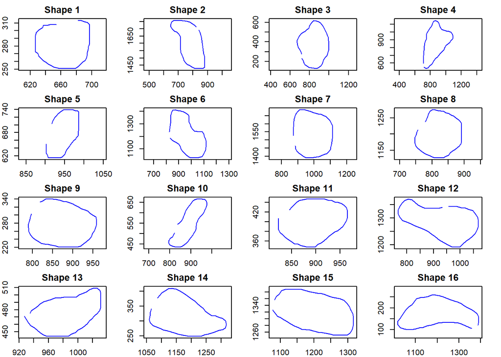

```
## Press [Enter] to view the next page...
```

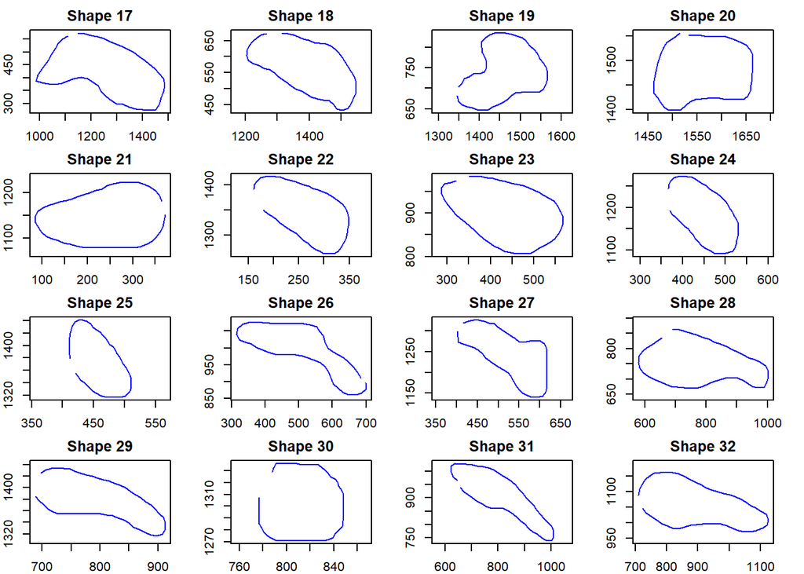

```
## Press [Enter] to view the next page...
```

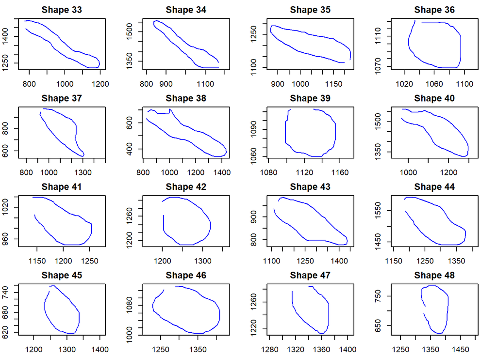

```
## Press [Enter] to view the next page...
```

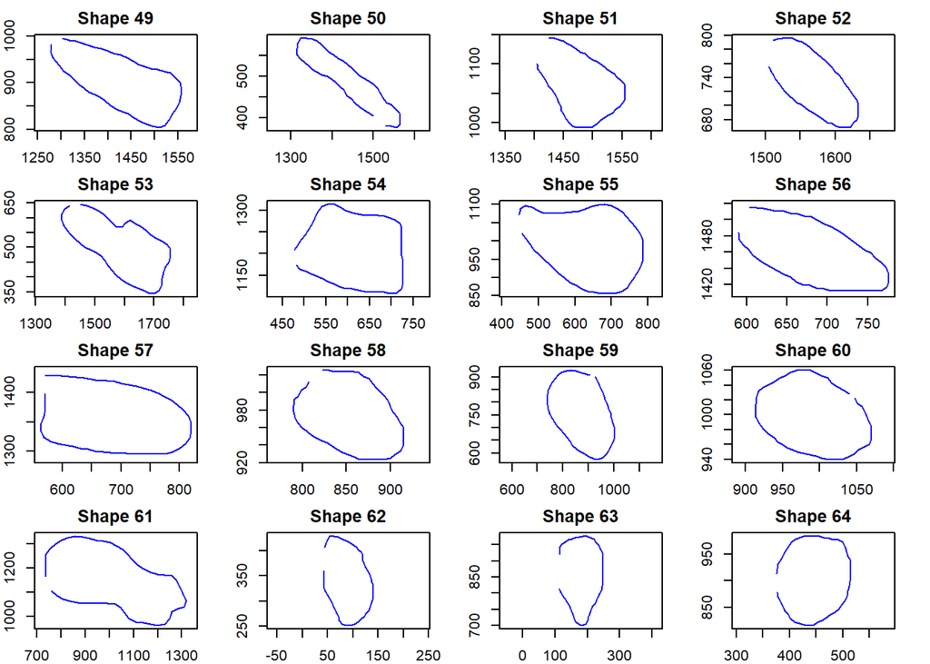

```
## Press [Enter] to view the next page...
```

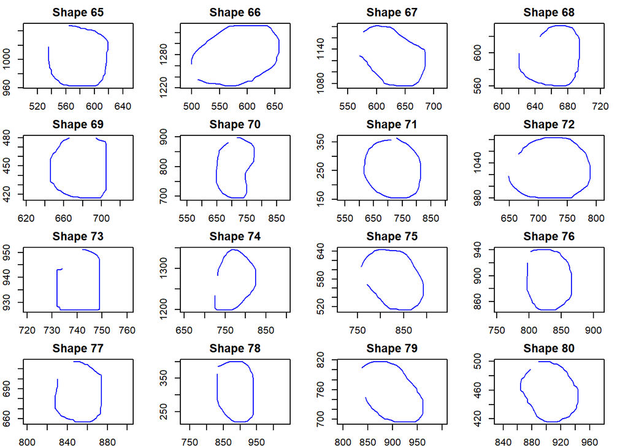

```
## Press [Enter] to view the next page...
```

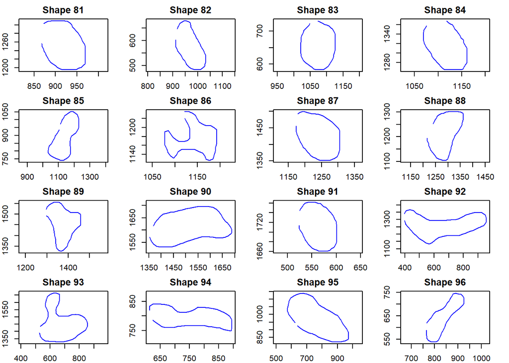

```
## Press [Enter] to view the next page...
```

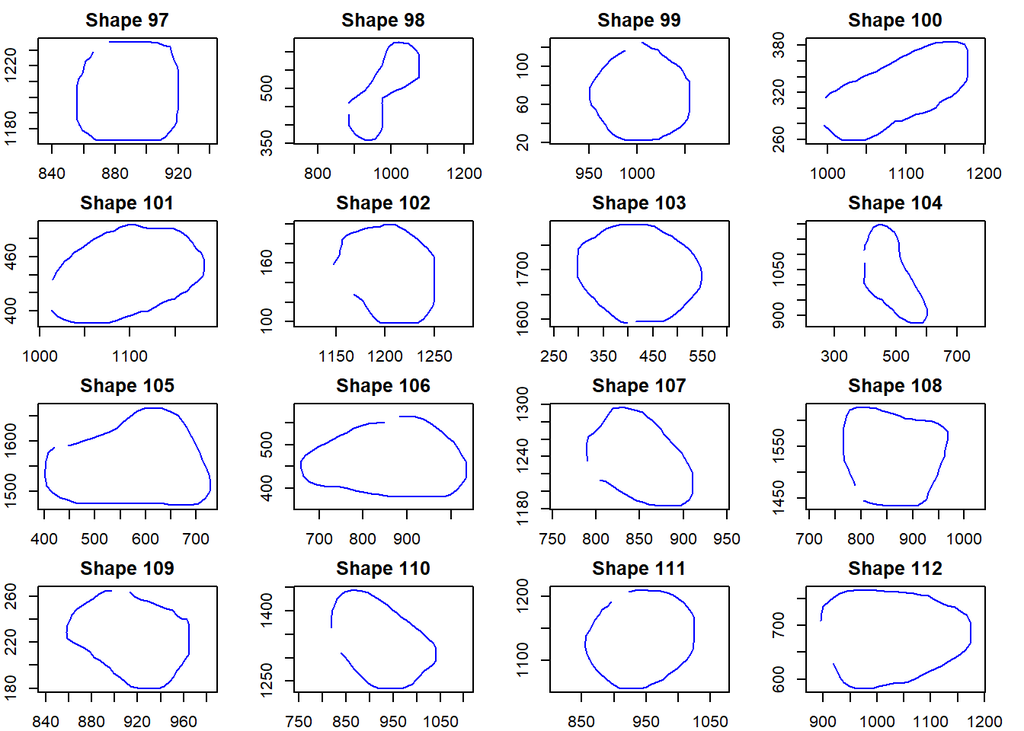

```
## Press [Enter] to view the next page...
```

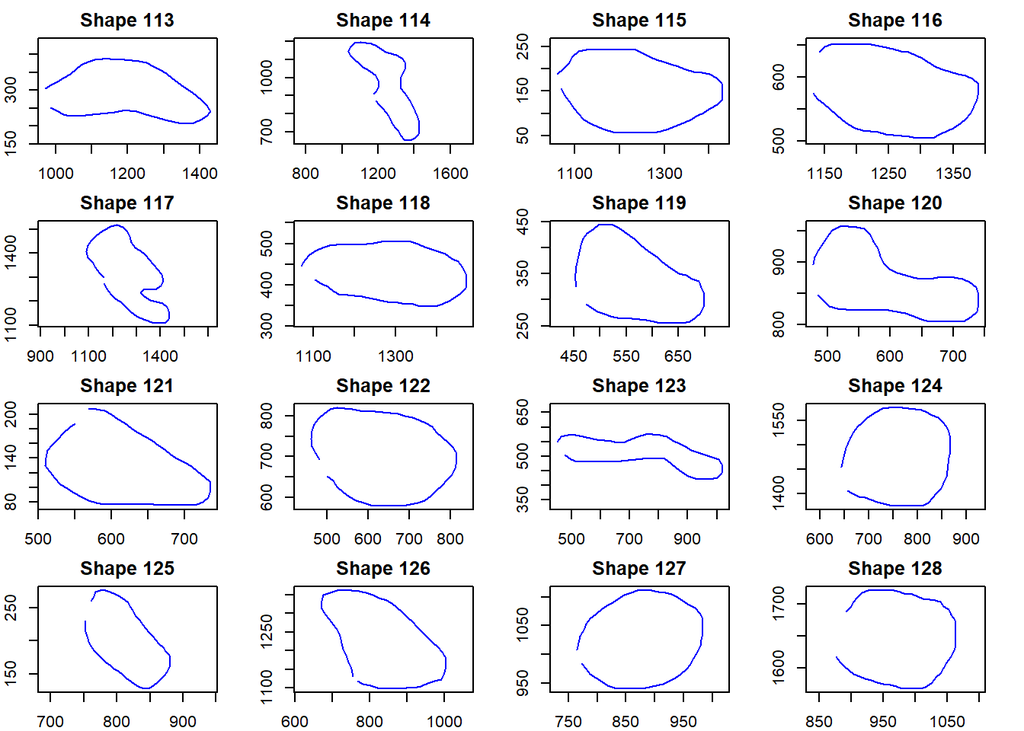

```
## Press [Enter] to view the next page...
```

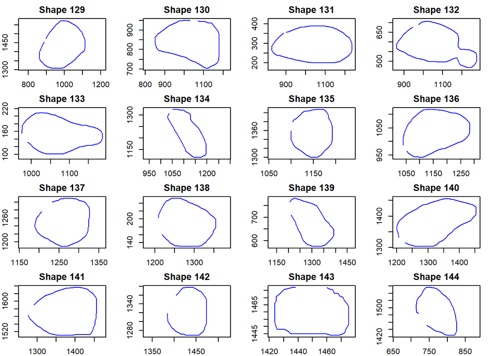

```
## Press [Enter] to view the next page...
```

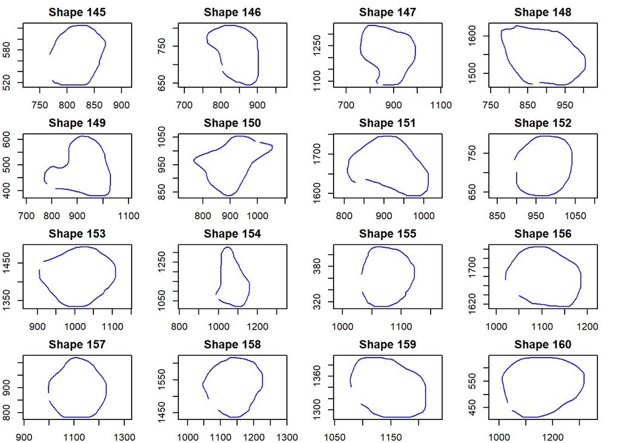

```
## Press [Enter] to view the next page...
```

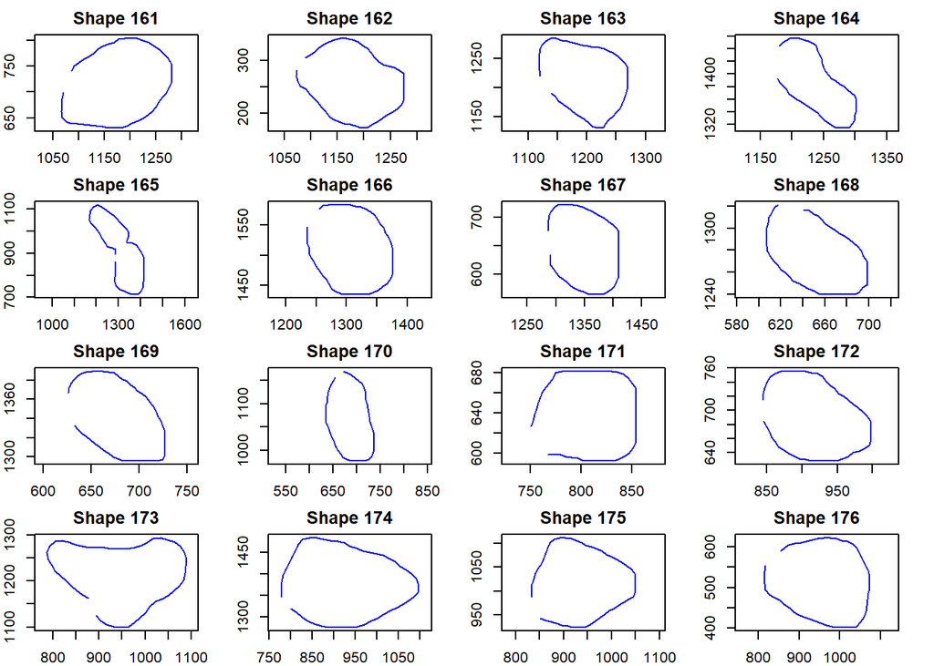

```
## Press [Enter] to view the next page...
```

```
## Press [Enter] to view the next page...
```

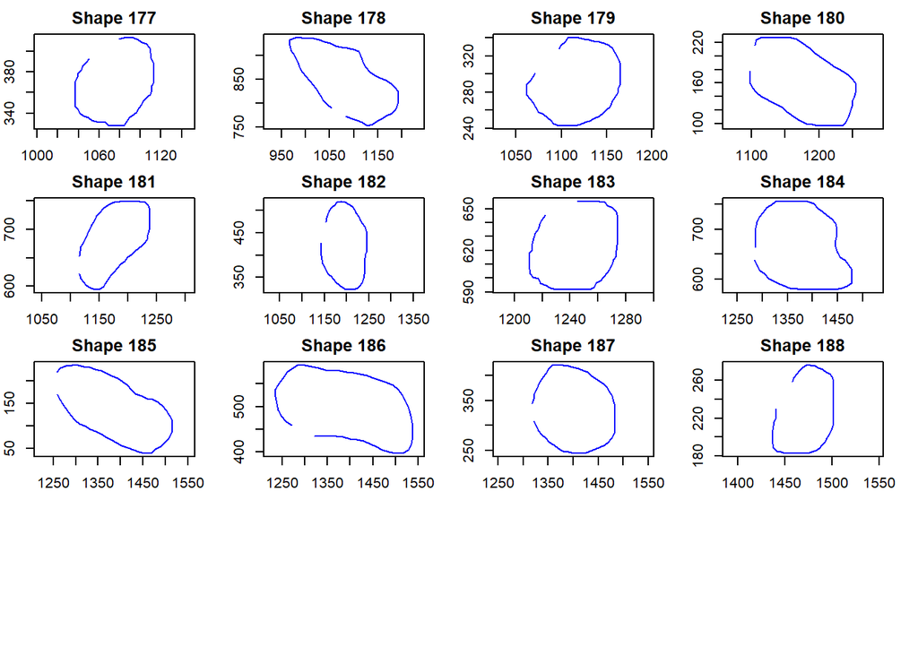

```r
# Extract mitochondria data for animal X1
mitochondria <- Allshape$X1

# Get the number of shapes for X1
num_shapes <- dim(mitochondria)[3]

# Set up a single plot layout for separate plots
par(mfrow = c(ceiling(sqrt(num_shapes)), ceiling(sqrt(num_shapes)))) # Square grid layout


# Set the number of plots per page (e.g., 16 plots per page)
plots_per_page <- 16
pages <- ceiling(num_shapes / plots_per_page)

for (page in 1:pages) {
  # Define the range of shapes to plot on this page
  start <- (page - 1) * plots_per_page + 1
  end <- min(page * plots_per_page, num_shapes)

  # Adjust layout for the current batch
  par(mfrow = c(4, 4), mar = c(2, 2, 2, 2)) # 4x4 grid with smaller margins

  # Plot each shape in the current batch
  for (i in start:end) {
    x_coords <- mitochondria[1, , i]
    y_coords <- mitochondria[2, , i]

    plot(x_coords, y_coords, type = "l", col = "blue",
         xlab = "", ylab = "", main = paste("Shape", i), asp = 1)
  }

  # Pause to view each page
  readline(prompt = "Press [Enter] to view the next page...")
}
```

Reading data.mat (same as Allshape.mat?)

```r
# Set the file path
data <- "data/data.mat"

# Read the .mat file
data <- readMat(data)

# Explore the structure of the loaded data
str(data)
```

```
## List of 36
##  $ D      : num [1:520, 1:459] 0.364 0.319 0.275 0.314 0.314 ...
##  $ N1     : num [1, 1] 520
##  $ N2     : num [1, 1] 459
##  $ X1     : num [1:2, 1:50, 1:188] 654 308 650 308 645 ...
##  $ X10    : num [1:2, 1:50, 1:225] 91 1425 89.5 1409 104.7 ...
##  $ X11    : num [1:2, 1:50, 1:161] 79 1377.5 88.2 1369 101 ...
##  $ X12    : num [1:2, 1:50, 1:170] 95 434 90 428 85 ...
##  $ X2     : num [1:2, 1:50, 1:151] 102 1158 108 1155 114 ...
##  $ X3     : num [1:2, 1:50, 1:181] 111 761 118 738 128 ...
##  $ X4     : num [1:2, 1:50, 1:203] 50 703 55 700.5 59.3 ...
##  $ X5     : num [1:2, 1:50, 1:216] 253 801 253 797 252 ...
##  $ X6     : num [1:2, 1:50, 1:196] 74.3 665.6 68.2 661 63 ...
##  $ X7     : num [1:2, 1:50, 1:108] 246 1018 254 995 257 ...
##  $ X8     : num [1:2, 1:50, 1:168] 633 1271 642 1261 653 ...
```

[output cut: 26 more lines]

### Reading classA.mat

Not sure what this is for - not included in the readme.txt file.

```r
# Set the file path
classA <- "data/classA.mat"

# Read the .mat file
classA <- readMat(classA)
```

### Reading A.mat

Not sure what this is for - not included in the readme.txt file.

```r
# Set the file path
A <- "data/A.mat"

# Read the .mat file
A <- readMat(A)
```

### Reading P_Elastic_scaled_cell.mat

```r
# Set the file path
P_Elastic_scaled_cell <- "data/P_Elastic_scaled_cell.mat"

# Read the .mat file
P_Elastic_scaled_cell <- readMat(P_Elastic_scaled_cell)
```

### Reading ScaledElasticDisMat.mat

ElasticDisMat.m

used to get the distance matrix between two groups/samples of shapes.

To improve effciency, I use parallel computing with “parfor”, it’s just “for” looping.

```r
# Set the file path
ScaledElasticDisMat <- "data/ScaledElasticDisMat.mat"

# Read the .mat file
ScaledElasticDisMat <- readMat(ScaledElasticDisMat)
```

### .mat files not used

ReSampleCurve.m Resample the original data to get N points on the boundary

plot_color_map.m to display the distance matrix between two samples/groups

Ex: folder–ElasticShapeScaled

ElasticDistance.m used to calculate the elastic scaled metric between two shapes/boundaries.

EnergyStat2sample.m used the calculate the energy statistic of two groups/samples

EnergyStatksample.m used the calculate the energy statistic of k groups/samples

PermutationTest.m use permutation test to get the p-value of energy test with energy statistic

TestStatistic.m to test the significance of one factor when it contains another significant factor. For example, to test the the significance of animal when it contains another significant factor–cell. I designed two test statistic: delta and epsilon but we think epsilon is better.

TwoAnimalPermutation.m use permutation test to get the p-value of of TestStatistic.m. Here, it’s only for two-sample test because of the mitochondria data. If you have k-sample, you can design k-sample test statistic like energy statistic.

GetDistanceMat.m to get the distance matrix. It takes a long time with elastic metrics and also large memory of the computer. You may want to get it step by step.

## Fitting Metric Halfspace Depth package

Reshape Data for All Animals

```r
# Initialize a list to store reshaped data for all animals
reshaped_data_all <- list()

# Loop through the animals (X1 to X12)
for (animal in names(Allshape)[1:12]) {
  mitochondria <- Allshape[[animal]]
  reshaped_data_all[[animal]] <- t(apply(mitochondria, 3, function(mat) c(mat[1, ], mat[2, ])))
}

# Check the structure of the reshaped data for all animals
str(reshaped_data_all)
```

```
## List of 12
##  $ X1 : num [1:188, 1:100] 654 823 720 719 902 ...
##  $ X10: num [1:225, 1:100] 91 300 353 242 371 ...
##  $ X11: num [1:161, 1:100] 79 247 341 453 523 ...
##  $ X12: num [1:170, 1:100] 95 125 139 164 284 ...
##  $ X2 : num [1:151, 1:100] 102 105 158 150 199 ...
##  $ X3 : num [1:181, 1:100] 111 205 247 251 283 ...
##  $ X4 : num [1:203, 1:100] 50 133 167 253 293 ...
##  $ X5 : num [1:216, 1:100] 253 390 316 322 423 ...
##  $ X6 : num [1:196, 1:100] 74.3 103 113.9 148 207.5 ...
##  $ X7 : num [1:108, 1:100] 246 420 345 487 489 ...
##  $ X8 : num [1:168, 1:100] 633 711 683 713 733 ...
##  $ X9 : num [1:183, 1:100] 74.4 57.5 127.3 297 851 ...
```

Compute Metric Halfspace Depth

```r
# Initialize a list to store MHD results for all animals
mhd_results_all <- list()

# Create Euclidean manifold
euclidean_mfd <- createM("Euclidean")

# Loop through all animals
for (animal in names(reshaped_data_all)) {
  # Get reshaped data for the current animal
  data <- reshaped_data_all[[animal]]

  # Ensure data and anchors are matrices
  data_matrix <- as.matrix(data)

  # Apply MHD function
  mhd_results_all[[animal]] <- MHD(
    mfd = euclidean_mfd,   # Manifold: Euclidean space
    data = data_matrix,    # Data points as matrix
    anchors = data_matrix, # Use data points themselves as anchors
    depthOnly = TRUE       # Only calculate depth values
  )
}


# Check results for one animal (e.g., X1)
mhd_results_all$X1
```

```
## $sampDeepest
##   [1]  850.7675  861.8139  873.5256  884.7267  896.2398  908.1875  919.3772
##   [8]  931.8029  944.2286  954.9935  964.9047  975.6524  985.8297  994.9718
##  [15] 1005.1803 1014.6126 1025.5176 1035.7779 1044.6309 1049.0000 1049.0000
##  [22] 1049.0000 1048.4262 1041.1026 1030.7428 1020.5404 1010.1812  999.0591
##  [29]  988.7457  979.2252  969.0457  958.3991  947.2030  937.1914  925.8510
##  [36]  915.5499  903.3519  890.9262  879.3289  871.4572  867.0948  863.0000
##  [43]  858.0000  853.5642  846.5656  841.0000  837.4897  834.0000  834.0000
##  [50]  834.0000  943.5860  939.0000  936.1186  933.9093  929.5068  927.0000
##  [57]  925.0000  925.0000  925.0000  930.9961  938.2698  944.3220  951.4149
##  [64]  958.9436  963.7268  971.4031  977.0000  983.3890  988.8154  999.7572
##  [71] 1012.1829 1024.6087 1036.8607 1046.8461 1053.2572 1060.2298 1066.9094
##  [78] 1071.9803 1077.2543 1084.0000 1088.0000 1092.3005 1096.0000 1101.0000
##  [85] 1105.2981 1110.4501 1111.0000 1111.0000 1109.0000 1101.9715 1091.1896
##  [92] 1079.6380 1068.6844 1057.2566 1047.5656 1036.9704 1025.4691 1013.8515
```

[output cut: 38 more lines]

Higher depth values indicate shapes that are more typical of the dataset.

Plot the depth values

```r
# Extract reshaped data for X1
x1_data <- reshaped_data_all$X1

# Extract depth values for X1
depthSamp <- mhd_results_all$X1$depthSamp

# Add depth values as a new column to the reshaped data
x1_data_with_depth <- cbind(x1_data, Depth = depthSamp)

# Display the first few rows to confirm mapping
head(x1_data_with_depth)
```

```
##
## [1,] 653.8172 649.6345 645.4517 641.3803 637.2093 636.0265 633.0000 630.3461
## [2,] 822.7690 809.9121 793.6548 777.5643 761.6318 744.4701 725.3084 705.9106
## [3,] 720.1553 733.6323 741.0000 751.2444 773.0645 794.5066 819.7739 844.6596
## [4,] 718.6039 745.6993 772.2716 791.1517 814.9990 833.8727 848.8430 868.6595
## [5,] 902.0000 902.0000 902.0000 902.0000 902.2636 905.0000 907.4662 913.3234
## [6,] 831.0000 846.3733 863.4296 882.4757 900.3517 911.7581 918.4630 927.7881
##
## [1,] 627.7590 627.0000 627.0000 627.0000  627.0000  627.0000  627.0000
## [2,] 686.5128 667.1151 653.8397 647.0000  649.0222  658.2370  671.7737
## [3,] 870.6698 893.5601 913.6535 929.9905  938.0000  946.4791  961.3739
## [4,] 890.8325 910.3636 930.7498 953.5383  976.3253  985.6451  999.4490
## [5,] 919.4901 925.6568 931.8236 937.9903  943.0000  946.6022  950.8938
## [6,] 942.8613 958.8297 976.2995 994.6636 1017.1788 1039.6939 1060.7949
##
```

[output cut: 83 more lines]

```r
# Loop through each mitochondria shape in X1
num_shapes <- nrow(x1_data_with_depth)
par(mfrow = c(5, 5)) # Arrange plots in a grid

# Save the plots to a PDF
pdf("X1_mitochondria_depth_plots.pdf", width = 10, height = 10)

# Adjust layout and margins
par(mfrow = c(5, 5), mar = c(1, 1, 2, 1))

# Map depth to each mitochondria shape for X1
depth_values <- mhd_results_all$X1$depthSamp

for (i in 1:nrow(reshaped_data_all$X1)) {
  x_coords <- reshaped_data_all$X1[i, 1:(ncol(reshaped_data_all$X1) / 2)]
  y_coords <- reshaped_data_all$X1[i, ((ncol(reshaped_data_all$X1) / 2) + 1):ncol(reshaped_data_all$X1)]

  plot(
    x_coords, y_coords, type = "l",
    main = paste("Depth:", round(depth_values[i], 3)),
    xlab = "", ylab = "", axes = FALSE
  )
}

dev.off()
```